# Project: Investigate a Dataset (Replace this with something more specific!)

### RESEARCH QUESTION 2: Investigate the Difference in Budget and Revenue for Each Genre

```python
# Select the columns that are useful for this reseach question.
# Use head function to check the output.
df = df[['genres','revenue','budget']]
df.head()
```

|  | genres | revenue | budget |
| --- | --- | --- | --- |
| 0 | Action\|Adventure\|Science Fiction\|Thriller | 1513528810 | 150000000 |
| 1 | Action\|Adventure\|Science Fiction\|Thriller | 378436354 | 150000000 |
| 2 | Adventure\|Science Fiction\|Thriller | 295238201 | 110000000 |
| 3 | Action\|Adventure\|Science Fiction\|Fantasy | 2068178225 | 200000000 |
| 4 | Action\|Crime\|Thriller | 1506249360 | 190000000 |

```
Text(0,0.5,'Difference in Revenue and Budget')
```

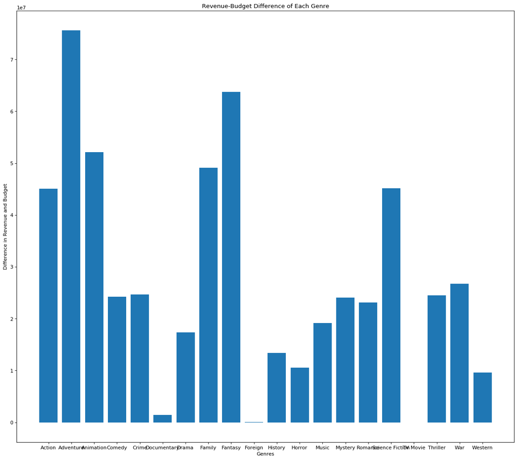

```python
# For each genre, calculate the difference in revenue and budget mean.
# Append the difference into a list called d.
# Plot a bar chart regarding genre and differences in revenue and budget mean.

genre = df['genres']
most_diff_min_max = 0
most_genre = ""
d = []

plt.figure(figsize=(18, 16), dpi= 80, facecolor='w', edgecolor='k')
for i in range (len(g)):
    A = df[genre.str.contains(g[i])]
    revenue_mean = A['revenue'].mean()
    budget_mean = A['budget'].mean()
    diff = revenue_mean - budget_mean
    d.append(diff)

plt.bar(g,d)
plt.title('Revenue-Budget Difference of Each Genre')
plt.xlabel('Genres')
plt.ylabel('Difference in Revenue and Budget')
```

```python
# Figure out the genre that has the greatest difference in movie revenue and budget.
g[np.argmax(d)]
```

```
'Adventure'
```

## Conclusions

> From question 1, the trend of popularity change of each movie genre till 2015 is obtained. The genre that has the greatest fluctuation in popularity these years is the 'Western'. As the line chart shown, the popularity of 'Adventure','Western', 'Science Fiction' and 'Action' movie is having a increasing trend.

> From question 2, the difference in revenue and budget of a single genre is shown in the bar chart above. 'Adventure' movies have the greatest revenue-budget difference.

> Combining the two questions together, since the 'Adventure' movies have an increasing popularity and large revenue-budget difference, directors may be suggested to increase the production of adventure movies in the future.

## Submitting your Project

> Before you submit your project, you need to create a .html or .pdf version of this notebook in the workspace here. To do that, run the code cell below. If it worked correctly, you should get a return code of 0, and you should see the generated .html file in the workspace directory (click on the orange Jupyter icon in the upper left).

> Alternatively, you can download this report as .html via the **File** > **Download as** submenu, and then manually upload it into the workspace directory by clicking on the orange Jupyter icon in the upper left, then using the Upload button.

> Once you've done this, you can submit your project by clicking on the "Submit Project" button in the lower right here. This will create and submit a zip file with this .ipynb doc and the .html or .pdf version you created. Congratulations!

```python
from subprocess import call
call(['python', '-m', 'nbconvert', 'Investigate_a_Dataset.ipynb'])
```